# **Fraud Detection Analysis**

# **1. Project Overview**

### Data Sources

The primary data for this project comes from the [PaySim Synthetic Mobile Money Transactions Dataset](https://www.kaggle.com/datasets/ealaxi/paysim1?resource=download), which contains one month of real-world mobile money transactions. PaySim’s logs include over 6 million records, with a variety of transaction types, customer behaviors, and injected fraudulent activity.

### Augmenting the Data with GANs

In addition to the original Kaggle data, this project demonstrates synthetic data generation using Generative Adversarial Networks (GANs). To further enrich the dataset, I generated additional synthetic data using a GANs, specifically CTGAN. GANs are powerful machine learning models that can learn the underlying distribution of a dataset and generate new, highly realistic records. They are a family of deep learning models that can learn the statistical properties of a real dataset and create entirely new, artificial records identical to real data (and you can always add rules/restrictions etc based on business needs).

- GANs allow us to create much larger and more varied datasets that are especially useful in rare event scenarios like fraud where we usually have a huge class imbalance, meaning way more non-fraud recaords vs. fraud for our models to learn from. This can be mediated using the class weighting parameters in any ML model but in my experience working with fraud data for various clients, I have found that augumentaion the dataset genereally improves model performance.
- We can inject or simulate new types of risk patterns and attributes, such as device, geo, behavioral, and flag-based features etc, as done for this project.

### Final Dataset

In this notebook, GANs are used (via the CTGAN implementation) to create the augmented synthetic dataset, `synthetic_fraud_200k.csv`, containing 200,000 synthetic transaction records. The process adds additional attributes such as device type, location, VPN usage, and risk flags by engineering these features.

### Data Ingestion and Synthetic Data Generation Steps

- Ingesting the original PaySim CSV (after download from Kaggle)
- Creating engineered features
- Training a GAN (CTGAN) on a stratified sample
- Generating and saving the synthetic dataset for modeling

```
Loaded creditcard.csv with shape: (6362620, 11)
```

|  | step | type | amount | nameOrig | oldbalanceOrg | newbalanceOrig | nameDest | oldbalanceDest | newbalanceDest | isFraud | isFlaggedFraud |
| --- | --- | --- | --- | --- | --- | --- | --- | --- | --- | --- | --- |
| 0 | 1 | PAYMENT | 9839.64 | C1231006815 | 170136.0 | 160296.36 | M1979787155 | 0.0 | 0.0 | 0 | 0 |
| 1 | 1 | PAYMENT | 1864.28 | C1666544295 | 21249.0 | 19384.72 | M2044282225 | 0.0 | 0.0 | 0 | 0 |
| 2 | 1 | TRANSFER | 181.00 | C1305486145 | 181.0 | 0.00 | C553264065 | 0.0 | 0.0 | 1 | 0 |
| 3 | 1 | CASH_OUT | 181.00 | C840083671 | 181.0 | 0.00 | C38997010 | 21182.0 | 0.0 | 1 | 0 |
| 4 | 1 | PAYMENT | 11668.14 | C2048537720 | 41554.0 | 29885.86 | M1230701703 | 0.0 | 0.0 | 0 | 0 |

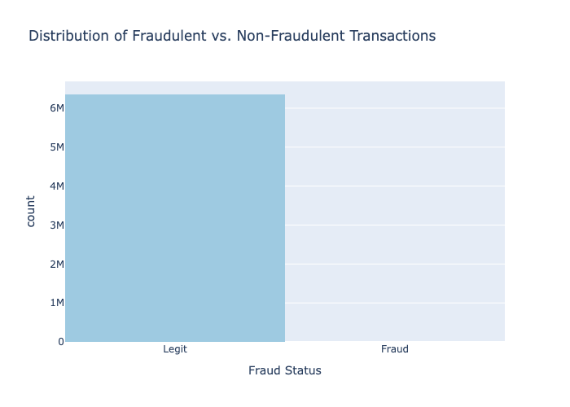

```
Plot 1: Fraud vs. Non-Fraud
```

Insight:

- Fraudulent transactions are only a tiny fraction of the total. These are real fraud data challenges where fraud rates are often under 1%.
- This code below is to augument the data further by adding engineered binary features to each record to simulate things like geography, device type, network risk (VPN, ISP), account behavior etc.
- This gives us a richer dataset to work with with added signals that arecommonly seen in real fraud data.

```
Augmented seed shape: (10000, 30)
```

|  | step | type | amount | nameOrig | oldbalanceOrg | newbalanceOrig | nameDest | oldbalanceDest | newbalanceDest | isFraud | ... | multi_account | repeat_txn | hour | night_txn | weekend_txn | flag_manual_review | email_link_clicked | two_factor_used | suspicious_ip | browser_tor |
| --- | --- | --- | --- | --- | --- | --- | --- | --- | --- | --- | --- | --- | --- | --- | --- | --- | --- | --- | --- | --- | --- |
| 0 | 162 | CASH_OUT | 183806.32 | C691771226 | 19391.00 | 0.00 | C1416312719 | 382572.19 | 566378.51 | 0 | ... | 0 | 0 | 18 | 0 | 1 | 0 | 0 | 0 | 0 | 0 |
| 1 | 137 | PAYMENT | 521.37 | C203378011 | 0.00 | 0.00 | M42773300 | 0.00 | 0.00 | 0 | ... | 0 | 0 | 17 | 0 | 1 | 0 | 0 | 0 | 0 | 0 |
| 2 | 179 | PAYMENT | 3478.18 | C1698571270 | 19853.00 | 16374.82 | M643984524 | 0.00 | 0.00 | 0 | ... | 0 | 0 | 11 | 0 | 0 | 0 | 0 | 0 | 0 | 0 |
| 3 | 355 | PAYMENT | 1716.05 | C913764937 | 5769.17 | 4053.13 | M1387429131 | 0.00 | 0.00 | 0 | ... | 0 | 0 | 19 | 0 | 0 | 0 | 0 | 0 | 0 | 0 |
| 4 | 354 | CASH_IN | 253129.93 | C2017736577 | 1328499.49 | 1581629.42 | C407484102 | 2713220.48 | 2460090.55 | 0 | ... | 0 | 0 | 18 | 0 | 0 | 0 | 0 | 0 | 0 | 0 |

5 rows × 30 columns

- This section below preps and trains a CTGAN model on our engineered fraud dataset.
- It first specifies which columns are continuous versus discrete (including all engineered risk and device flags), builds the training DataFrame, and converts all continuous columns to numeric just in case.
- The CTGAN is then trained to learn the structure of the data is used to generate 200K synthetic records.
- New records are saved as a CSV for use later in the EDA, feature engineering, and modeling.

|  | step | amount | oldbalanceOrg | newbalanceOrig | oldbalanceDest | newbalanceDest | type | isFraud | isFlaggedFraud | loc_US | ... | new_account | multi_account | repeat_txn | night_txn | weekend_txn | flag_manual_review | email_link_clicked | two_factor_used | suspicious_ip | browser_tor |
| --- | --- | --- | --- | --- | --- | --- | --- | --- | --- | --- | --- | --- | --- | --- | --- | --- | --- | --- | --- | --- | --- |
| 0 | 227 | 95909.435473 | 5.987431e+04 | 2.770631e+04 | 1.747369e+06 | 257156.759143 | CASH_OUT | 0 | 0 | 0 | ... | 1 | 0 | 0 | 0 | 0 | 0 | 0 | 1 | 0 | 0 |
| 1 | 222 | 737185.160237 | 4.955387e+05 | 5.042004e+06 | -2.468791e+03 | -42445.557978 | TRANSFER | 1 | 0 | 1 | ... | 1 | 0 | 0 | 0 | 0 | 1 | 0 | 0 | 0 | 1 |
| 2 | 241 | 238143.130890 | 1.896308e+06 | 1.505911e+04 | -7.137616e+02 | -31865.367296 | TRANSFER | 0 | 0 | 1 | ... | 0 | 0 | 0 | 0 | 0 | 0 | 0 | 1 | 0 | 1 |
| 3 | 31 | 233793.904256 | 5.211977e+04 | -7.789024e+02 | 6.086390e+04 | 385003.911782 | CASH_OUT | 1 | 0 | 0 | ... | 0 | 1 | 0 | 0 | 0 | 0 | 0 | 0 | 0 | 1 |
| 4 | 341 | 179832.603566 | 8.090784e+04 | 6.250140e+06 | 5.490266e+04 | 37890.704992 | PAYMENT | 0 | 0 | 1 | ... | 0 | 0 | 0 | 0 | 0 | 0 | 0 | 0 | 0 | 0 |

5 rows × 27 columns

# **2. Feature Engineering: Translating Domain Knowledge into Additional Features**

- After reviewing the data and main risk indicators, I create new features that capture fraud-related behavior, like account draining, risk flag counts, and device or location usage patterns.
- This step includes one-hot encoding categorical variables, applying log transforms to skewed numeric fields, and handling missing values.
- The goal is to give the models better information so the models can more effectively identify fraud patterns.

## Engineering Fraud-Focused Features and Cleaning Data

- This function creates new variables that capture fraud risk factors, ratio-based features, operational flags, and time-based patterns.
- Log scaling helps control for outliers; ratios highlight unusual behavior, and counting risk flags help with identifying txns with multiple warnings sign.
- One-hot encoding or normalize/stadardizing the data may not be needed for boosting algorithms since they can do that autmatically but are generally just easier to work with when modelling.
  - One-hot encoding is usually still needed for categorical variables (even for boosting trees, unless they natively support categorical handling, like in CatBoost, LightGBM) but is generally not needed for tree-based methods (like XGBoost, LightGBM, CatBoost), as they are not sensitive to feature scale, but it doesn’t hurt.
  - The main benefit of encoding/scaling is “consistency” across different models, and sometimes for interpretability or pre-processing pipelines.

```
Shape after feature engineering: (200000, 49)
```

Insights:

- The resulting dataframe now contains the following new features:
  - Amount ratios (`amt_over_oldbal`, `amt_over_destbal`): If transactions are unusually high compared to the available balance, these features can help spot draining, laundering, or suspicious fund movement.
  - Balance change features (`org_balance_delta`, `dest_balance_delta`): Useful for flagging rapid or unexpected changes in account balances, which are often warning signs of fraud.
  - Account draining indicators (`drain_amount`, `drained_to_zero`): Catches scenarios where an account is fully emptied in a single move, which could indicate account takeover (ATO).
  - High-amount and type-specific outlier flag: Highlights if a transaction is much larger than others, flagging it as a potential anomaly.
  - Time-based variables (`hour`, `day_of_week`, `is_night`, `is_weekend`): These may provide insight into when fraud is more likely to occur, such as during nights or weekends.
  - Risk stacking (`risk_factor_count`): Counts the number of separate risk signals to spot transactions with multiple suspicious indicators.
  - In real financial fraud data, there is usually an opportunity to create several more engineered features depending on what features the business has.
    - For example, if account balances, transaction amounts, etc., are provided, many more features can be created. Such features can be bucketed or used to create new interaction features.
    - This analysis does not get into interaction features, but in my real-world work, these are very useful to create and are quite important when modeling.
    - In essence, you should help the model understand underlying patterns as best as possible via engineered features created using interactions between existing features (like multiplying key numerical columns, ratios, boolean flags, cross features, etc.).
    - Before any modeling, it is good practice to run the features through a feature importance algorithm before and after modeling (using things like permutation importance or SHAP).

# **3. Exploratory Data Analysis (EDA)**

**EDA Summary:**

- Load the synthetic fraud dataset and check structure with summary statistics.
- Visualize the class balance to understand the ratio of fraud to non-fraud txns.
- Plot key numeric features, split by fraud status to see which variables separate the classes best.
- Highlight the top features that most distinguish fraud cases using bar charts of means and fraud rates.
- Examine operational, device, and location risk signals by plotting fraud rates for each category.
- Use correlation heatmap to find which features are closely related to the fraud flag.
- Analyze transaction timing with charts by hour of day and day of week to pick up on temporal fraud patterns.
- Segment results by recipient type, such as merchant versus customer, to find group specific trends.

|  | step | amount | oldbalanceOrg | newbalanceOrig | oldbalanceDest | newbalanceDest | isFraud | isFlaggedFraud | loc_US | loc_EU | ... | dest_balance_delta | drain_amount | drained_to_zero | high_amt_for_type | is_night | day_of_week | is_weekend | suspicious_zero_dest_after | dest_was_zero_before | risk_factor_count |
| --- | --- | --- | --- | --- | --- | --- | --- | --- | --- | --- | --- | --- | --- | --- | --- | --- | --- | --- | --- | --- | --- |
| count | 200000.00000 | 2.000000e+05 | 2.000000e+05 | 2.000000e+05 | 2.000000e+05 | 2.000000e+05 | 200000.000000 | 200000.000000 | 200000.000000 | 200000.000000 | ... | 2.000000e+05 | 2.000000e+05 | 200000.0 | 200000.000000 | 200000.0 | 200000.000000 | 200000.000000 | 200000.0 | 200000.0 | 200000.000000 |
| mean | 318.21926 | 7.429056e+05 | 1.836462e+06 | 8.270489e+05 | 8.392850e+05 | 9.625212e+05 | 0.483990 | 0.011930 | 0.675875 | 0.171405 | ... | 8.000199e+01 | 1.009413e+06 | 0.0 | 0.100010 | 0.0 | 2.507265 | 0.230965 | 0.0 | 0.0 | 1.342765 |
| std | 197.62011 | 1.551625e+06 | 3.522702e+06 | 2.667762e+06 | 2.324462e+06 | 1.857545e+06 | 0.499745 | 0.108571 | 0.468048 | 0.376863 | ... | 3.627426e+04 | 4.349938e+06 | 0.0 | 0.300014 | 0.0 | 2.016129 | 0.421451 | 0.0 | 0.0 | 1.373148 |
| min | -15.00000 | -1.990170e+05 | -2.072690e+05 | -9.552883e+05 | -9.777555e+04 | -1.849315e+05 | 0.000000 | 0.000000 | 0.000000 | 0.000000 | ... | -4.914852e+05 | -2.689601e+07 | 0.0 | 0.000000 | 0.0 | 0.000000 | 0.000000 | 0.0 | 0.0 | 0.000000 |
| 25% | 187.00000 | 8.191075e+04 | 5.831217e+04 | -1.347123e+04 | 1.783869e+04 | -3.490452e+04 | 0.000000 | 0.000000 | 0.000000 | 0.000000 | ... | -1.694071e+00 | 1.503533e+04 | 0.0 | 0.000000 | 0.0 | 1.000000 | 0.000000 | 0.0 | 0.0 | 0.000000 |
| 50% | 302.00000 | 2.618191e+05 | 4.156650e+05 | 1.817535e+03 | 5.119432e+04 | 1.970625e+04 | 0.000000 | 0.000000 | 1.000000 | 0.000000 | ... | -6.145672e-01 | 2.109223e+05 | 0.0 | 0.000000 | 0.0 | 2.000000 | 0.000000 | 0.0 | 0.0 | 1.000000 |
| 75% | 405.00000 | 4.826244e+05 | 1.770174e+06 | 1.069875e+05 | 5.639284e+05 | 1.333341e+06 | 1.000000 | 0.000000 | 1.000000 | 0.000000 | ... | 1.767037e+00 | 1.505619e+06 | 0.0 | 0.000000 | 0.0 | 4.000000 | 0.000000 | 0.0 | 0.0 | 3.000000 |
| max | 802.00000 | 1.179751e+07 | 3.467394e+07 | 2.698096e+07 | 3.518277e+07 | 2.061397e+07 | 1.000000 | 1.000000 | 1.000000 | 1.000000 | ... | 1.620949e+07 | 3.469029e+07 | 0.0 | 1.000000 | 0.0 | 6.000000 | 1.000000 | 0.0 | 0.0 | 4.000000 |

8 rows × 49 columns

## Visualizing Fraud Class

**Distribution of Fraud vs. Non-Fraud Transactions**

- This plot shows that the synthetic dataset was created with a balanced number of fraudulent and non-fraudulent transactions.
- A balanced class distribution like this is useful for model development and benchmarking, as it removes the extreme class imbalance that is common in real-world fraud data as mentioned earlier.

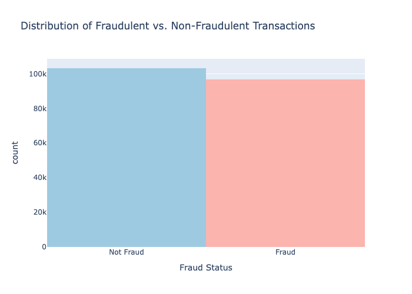

```
Plot 2: Fraud vs. Non-Fraud after sample and GANs
```

## Visualizing Top 15 Features with Greatest Difference in Class (fraud vs non fraud)

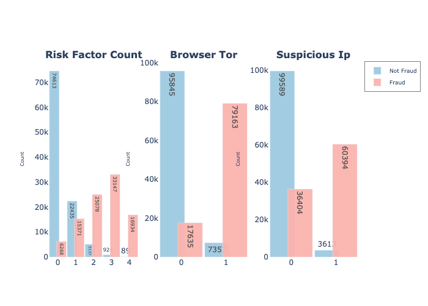

```
Plot 3: Fraud vs. All Categorical
```

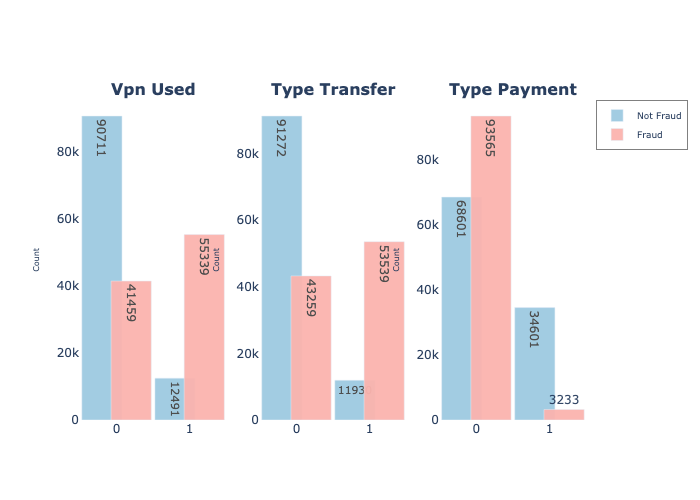

```
Plot 3: Fraud vs. All Categorical
```

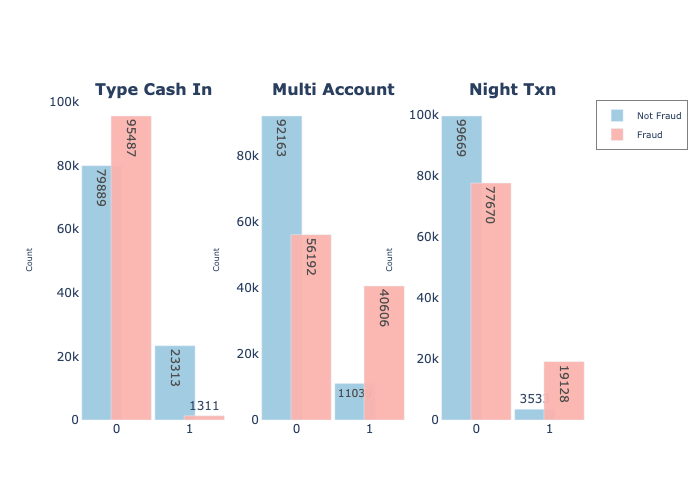

```
Plot 3: Fraud vs. All Categorical
```

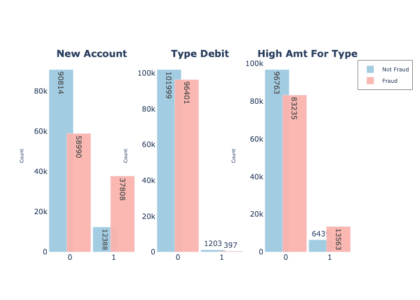

```
Plot 3: Fraud vs. All Categorical
```

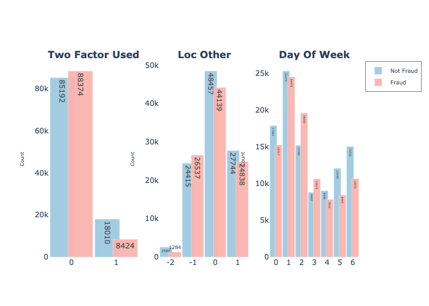

```
Plot 3: Fraud vs. All Categorical
```

## Time-Based Feature Distributions by Fraud Status

- This code defines and uses a helper function to plot the distributions time based features created from the 'step' column we were provided, by the fraud label.

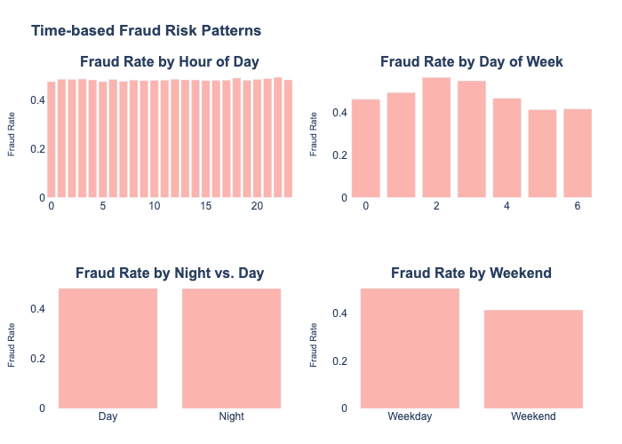

```
Plot 4: Fraud vs. Time based features
```

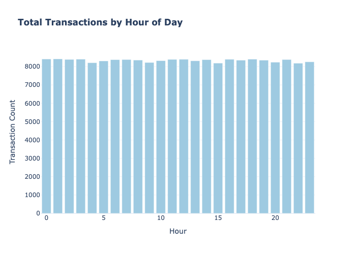

```
Plot 5: Fraud vs. Transaction count over hour of day
```

## Fraud Counts by Transaction Type

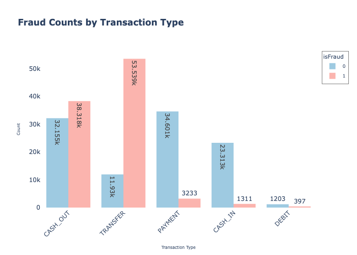

```
Plot 6: Fraud Counts by Transaction Type
```

Insights:

- Fraud is heavily concentrated in CASH_OUT and TRANSFER transactions. These types account for the vast majority of fraud cases in the data.
- Legitimate transactions make up the bulk of PAYMENT and CASH_IN activity, with very few fraud cases in these categories.
- Both fraud and non-fraud counts are low for DEBIT, indicating this type is rare overall.
- Transaction type clearly separates risky from safe activity, making it a key feature for our fraud model.

## Exploring Risk Flags, Device, and Geo Patterns

- This section focuses on risk signals such as VPN use, TOR browser (The Onion Router), suspicious IP, device type, and manual review triggers.
- Fraud rates for each flag, highlighting which features actually separate fraud from normal activity and visualized below.

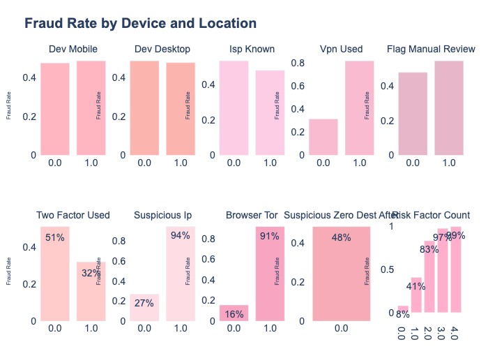

```
Plot 7: Fraud Counts by Fraud Rate by Device and Location and Other Similar Features
```

## Investigating Correlations Among Features

- This correlation heatmap compares the relationships between the top 25 categorical and binary features and the fraud target using Cramer’s V, a correlation measure which is suited for categorical vars.
- Cramer’s V is used here because it handles binary and multi-class features, and finds non-linear associations that might be missed by linear methods.
- The upper triangle heatmap displays all pairwise correlations, with red boxes marking feature pairs that are significantly related.

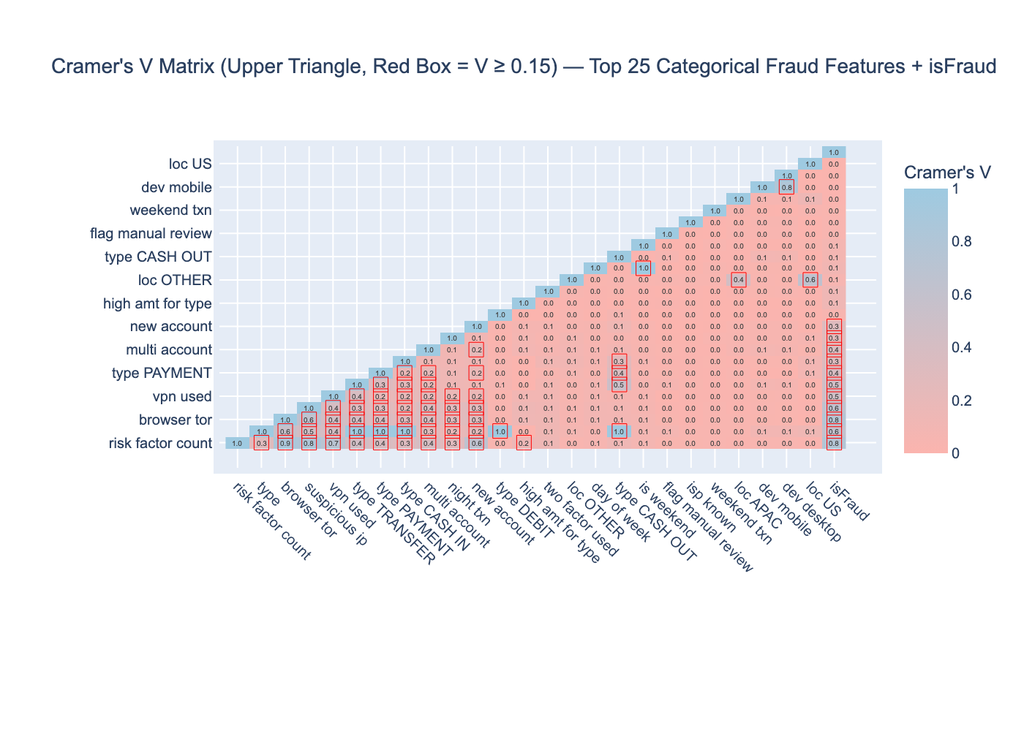

```
Plot 8: Cramer's V Correlation Heatmap
```

Insights:

- Risk factor count has strong overlap with key risk flags like browser_tor and suspicious_ip, which makes sense since it aggregates these indicators.
- Several fraud flags, including suspicious_ip, browser_tor, vpn_used, and type_TRANSFER, often appear together in the same transactions.
- Transaction type and device features show much weaker correlation, meaning they add fresh signals that aren’t just repeats of other risk flags.
- No signs of direct leakage but the stacked risk feature, 'risk factor count' is highly related and could be a cuase of collinearity in the model.

# **4. Hyperparameter Tuning and Model Training**

- We will be training 3 models to compare performnace and be thorough.
- With the new features engineered, the next step will be to tune each model’s key parameters to get the best possible fraud detection performance.
- Grid search and cross-validation are used to find the optimal hyperparameters.
- Hyperparameter tuning will be done before final training and testing, which keeps evaluation realistic and ensures all models are compared fairly.
- Three models are trained and evaluated: Logistic Regression for a baseline, plus Random Forest and LightGBM as our main prediction models. Performance is measured using AUC/ROC and precision-recall metrics.
- Depending on the client, they may be more interested in simply minimizing false positives or reducing false negatives, depending on their incurred costs when losing a potential customer or when allowing a fraudster through.

## Hyperparameter Tuning with Grid Search

- Splitting the dataset into training and testing partitions, using stratification to maintain the same fraud rate in both sets.
- This code below runs grid search over multiple combinations of tree depth, number of trees, and other model settings for both Random Forest and LightGBM. The best hyperparameters are then selected for final model evaluation.
- The code will also save the best hyperparameters into a local drive to avoid rerunning the code and maintaining consistent models.

```
Loading model from /Users/aryankaushik/Downloads/fraud_project_files/best_rf_model.pkl
Loading model from /Users/aryankaushik/Downloads/fraud_project_files/best_lgbm_model.pkl
```

## Model Training and Evaluation with Multiple Metrics

- Each model is trained and tested using a full set of evaluation metrics, including ROC AUC, precision-recall AUC, and the confusion matrix.
- ROC and precision-recall curves help show how well the model separates fraud from non-fraud, even when the data is imbalanced.
- The confusion matrix summarizes the true positives, false positives, showing exactly where the model succeeds and where it struggles.

```
=== Logistic Regression ===
ROC AUC: 0.789 | PR AUC: 0.786 | F1: 0.687
Classification report:
               precision    recall  f1-score   support

           0       0.70      0.81      0.75     20640
           1       0.76      0.63      0.69     19360

    accuracy                           0.72     40000
   macro avg       0.73      0.72      0.72     40000
weighted avg       0.73      0.72      0.72     40000

Confusion matrix:
 [[16711  3929]
 [ 7164 12196]]
```

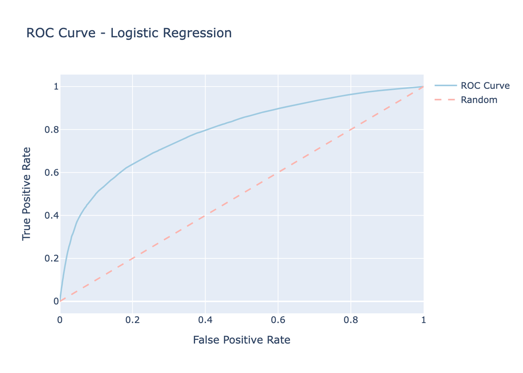

```
Plot 9: ROC Curve
```

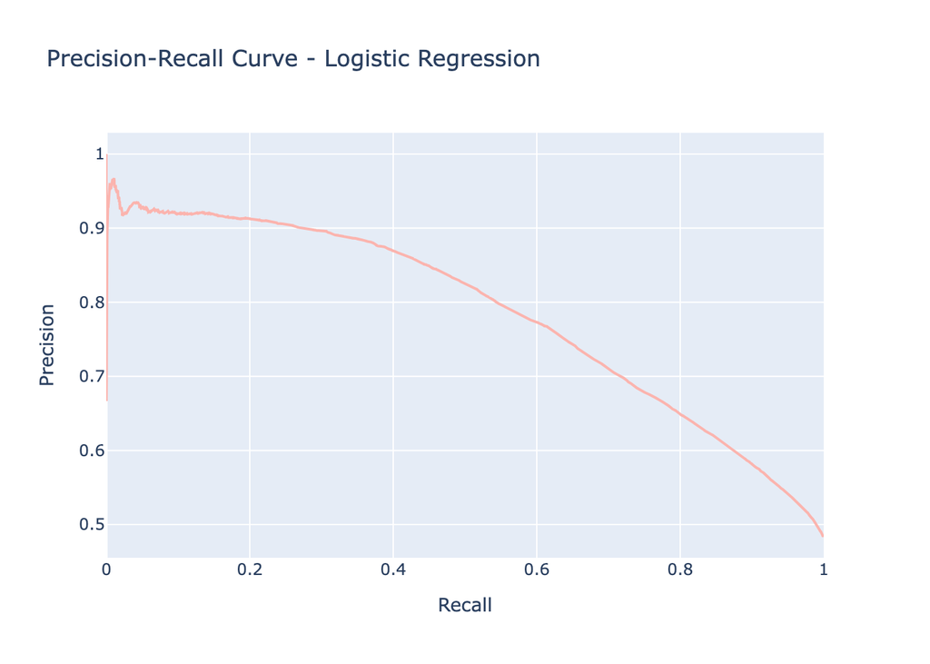

```
Plot 9b: PR Curve
```

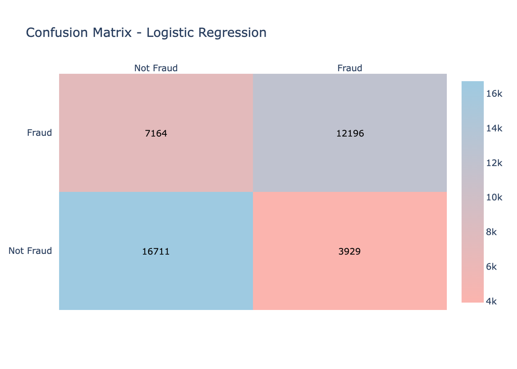

```
Plot 10: Model Results

=== Random Forest ===
ROC AUC: 0.947 | PR AUC: 0.947 | F1: 0.875
Classification report:
               precision    recall  f1-score   support

           0       0.88      0.89      0.88     20640
           1       0.88      0.87      0.87     19360

    accuracy                           0.88     40000
   macro avg       0.88      0.88      0.88     40000
weighted avg       0.88      0.88      0.88     40000

Confusion matrix:
 [[18315  2325]
 [ 2498 16862]]
```

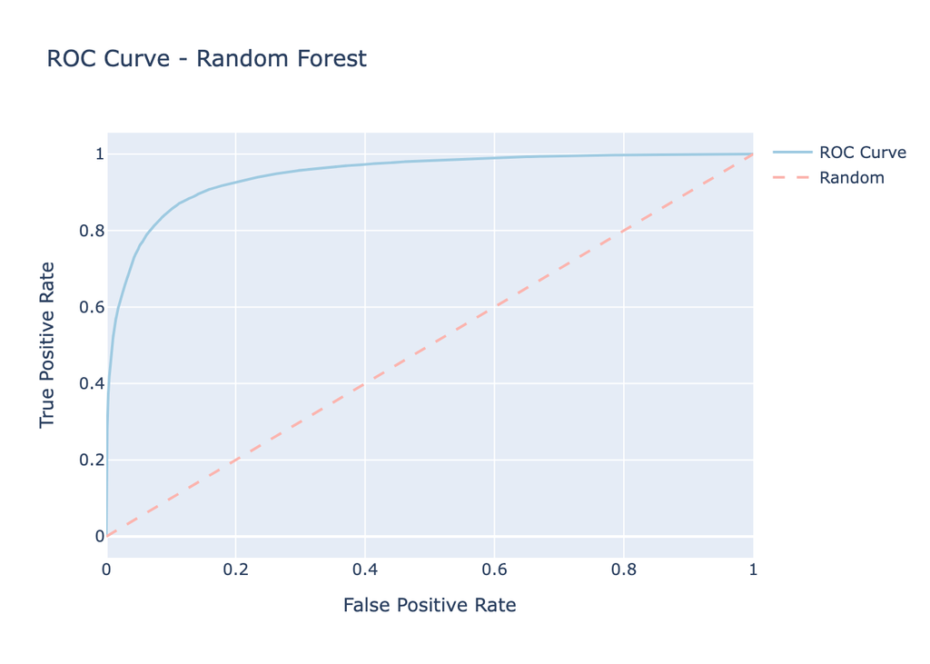

```
Plot 9: ROC Curve
```

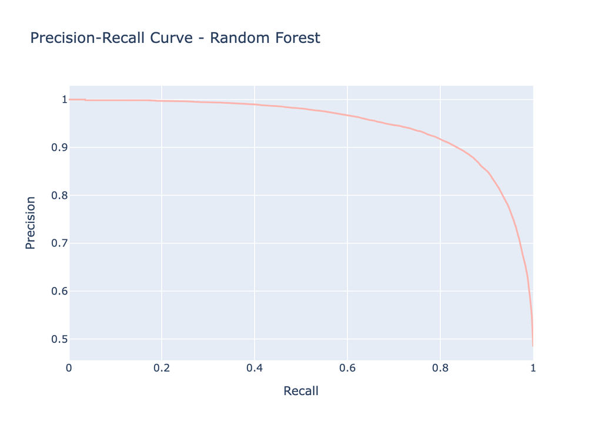

```
Plot 9b: PR Curve
```

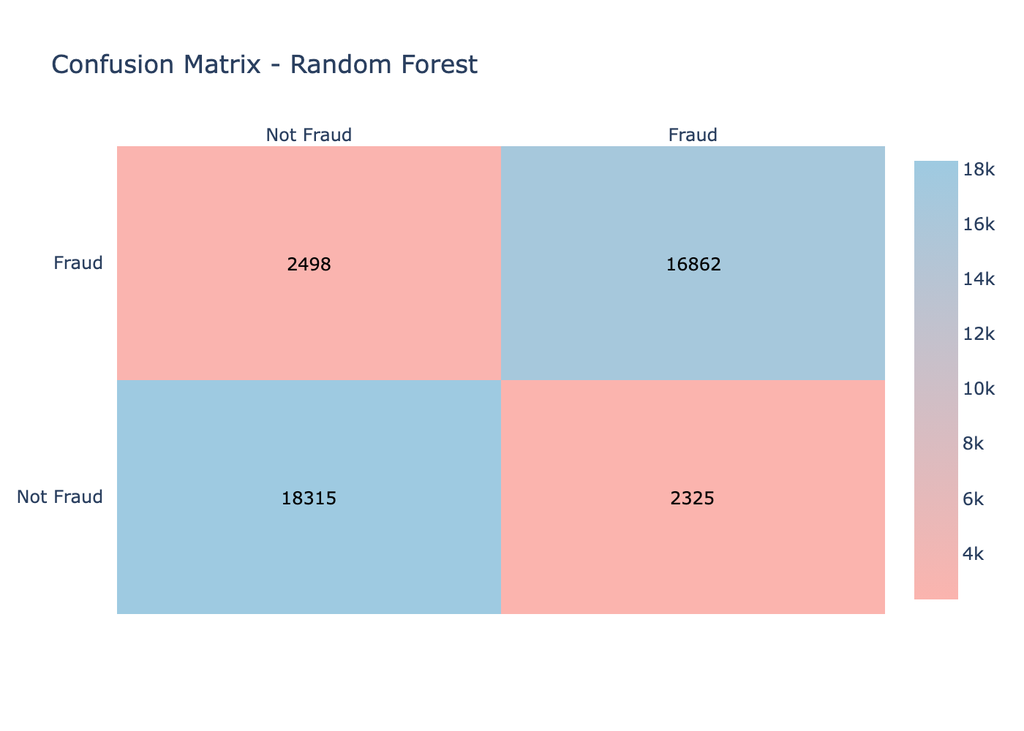

```
Plot 10: Model Results

=== LightGBM ===
ROC AUC: 0.951 | PR AUC: 0.952 | F1: 0.877
Classification report:
               precision    recall  f1-score   support

           0       0.88      0.89      0.89     20640
           1       0.88      0.87      0.88     19360

    accuracy                           0.88     40000
   macro avg       0.88      0.88      0.88     40000
weighted avg       0.88      0.88      0.88     40000

Confusion matrix:
 [[18443  2197]
 [ 2538 16822]]
```

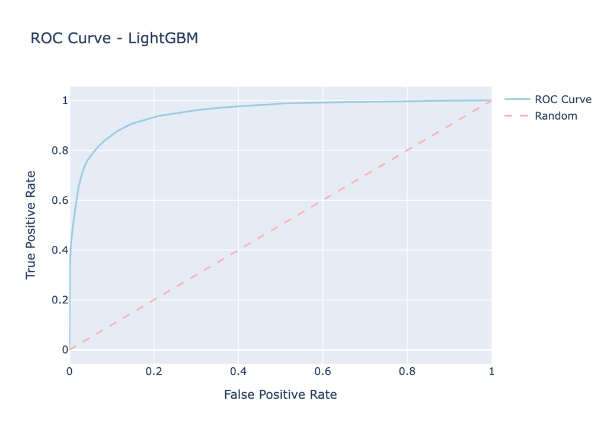

```
Plot 9: ROC Curve
```

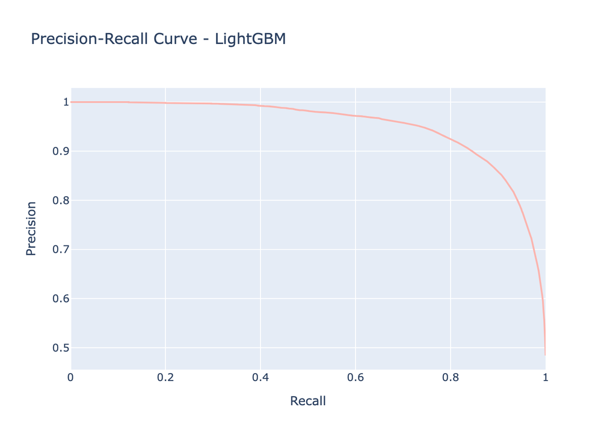

```
Plot 9b: PR Curve
```

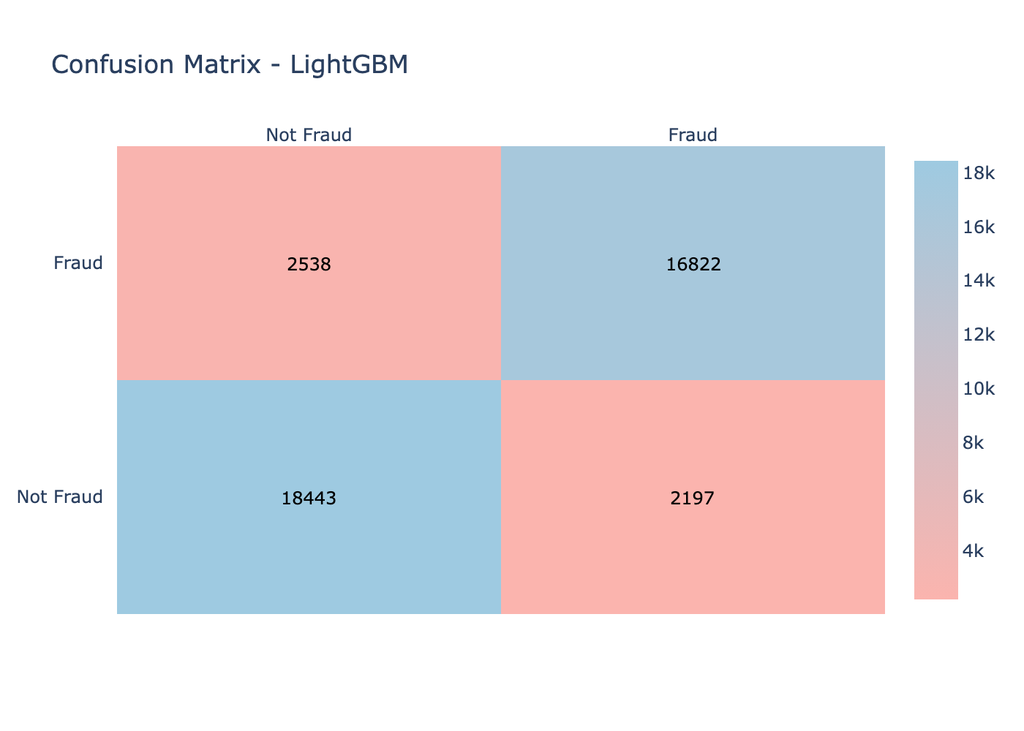

```
Plot 10: Model Results
```

# 📖 **5. Model Explainability**

- SHAP values are used here to show which features have the biggest impact on LightGBM’s predictions. This helps clarify what the model focuses on overall and also how it makes decisions on specific transactions..

## SHAP Bubble Chart (Mean |SHAP| Impact per Feature)

This plot shows the average absolute impact of each feature across the whole test set.

The bubble size tells us how much, on average, that a feature moves the model’s prediction (regardless of direction, positive or negative).

It shows us which features are most important for the model.

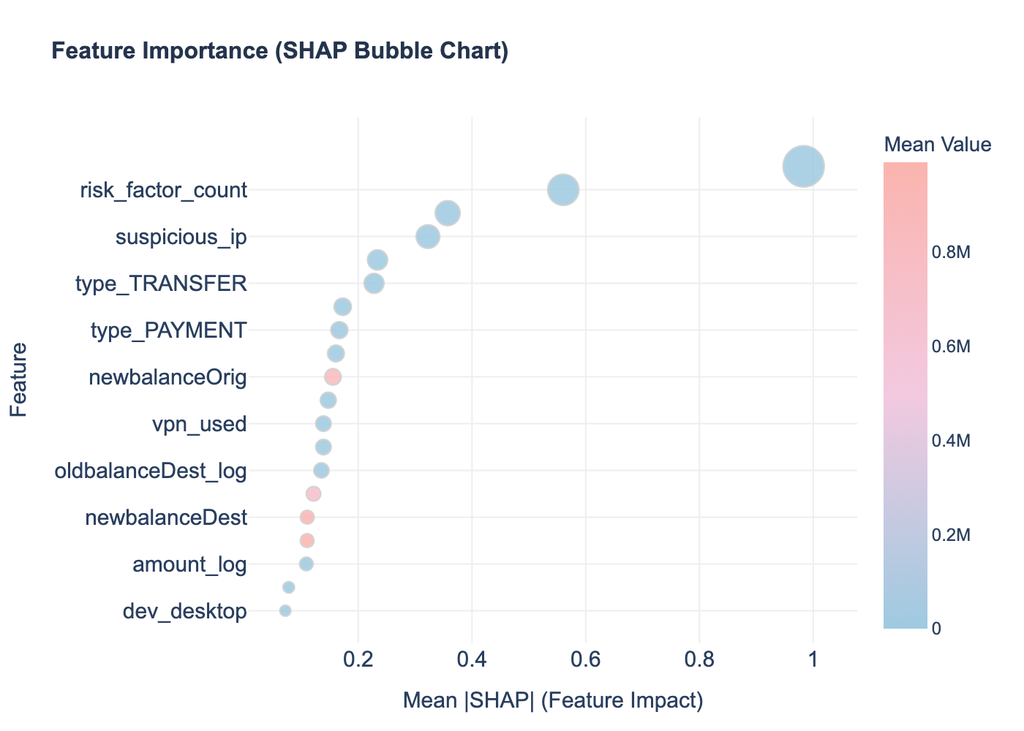

```
Plot 11:SHAP Bubble Chart for Model Feature Performance
```

Insights:

- browser_tor and risk_factor_count seem to be the top features, meaning that overall they are most influential in pushing the model towards predicting fraud or not fraud.
- Features like step, suspicious_ip, and night_txn also show strong mean impact, signaling they consistently influence the prediction outcome.
- The bubble sizes make it easy to compare overall importance and the colour gradient adds context about each feature’s typical value across the test set.
- This plot helps spot the highest value features and gives us an idea for future feature selection when remodeling.

## SHAP Beeswarm Plot:

- This plot shows the individual transaction in our test set. Dots are spread out horizontally by their SHAP value (how much the feature pushed that specific prediction higher or lower for fraud).
- It tells us how much each feature is influencing the model in different directions (positive/negative).

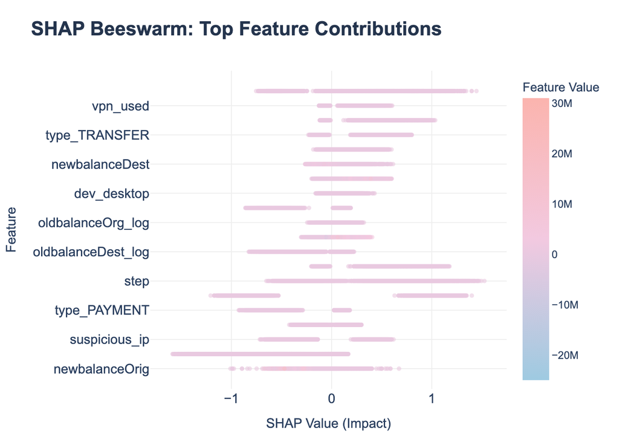

```
Plot 12:SHAP Beeswarm Chart for Top Feature Contributions
```

Insights:

# **6. What This Project Achieved**

[figure not shown]